# Fitness Tracker Analysis

Gaurav Grewal

10-31-2024

## Introduction

Hello! This is a Fitness Tracker data analysis project I am doing for the Capstone project module as part of my Google Data Analytics certification. In this case study, I will perform many real-world tasks of a data analyst. I will imagine I am working for a high-tech manufacturer of health-focused products like a smart watch or a fitness band for men & women, and meet different team members. In order to answer the key business questions, I will follow the steps of the data analysis process: **ask**, **prepare**, **process**, **analyze**, **share** and **act**.

By the end of this project, I will have hopefully demonstrated to you with this case study some of the skills I’ve acquired through my certification.

## Scenario

I am a Data Analyst working on the marketing analyst team. The high-tech manufaturer is a successful company but they have the potential to become a larger player in the global smart device market. The co-founder & chief creative officer believes that analyzing smart device fittness data could help unlock new growth opportunities for the company. I have been asked to focus on one of the products and analyze smart device data to gain insight into how consumers are using their devices. The insights you discover will then help guide marketing strategy for the company.

## Phase 1: Ask

The goal of this phase is to identify a clear statement of business task and consider key stakeholders.

### 1.1 Goal

The goal is to identify how consumers use smart devices and apply insights into the company’s marketing strategy to improve consumer health.

### 1.2 Stakeholders

The final presentation will be given to the following stakeholders:

1. Co-founders
2. Chief Creative Officer
3. Member of the executive team
4. Director of Marketing

## Phase 2: Prepare

The goal of this phase is to identify the data sets we need to use for our analysis. Verify the privacy, accessibility and security concerns with this data.

### 2.1 Datasets

The datasets used for this case study is FitBit Fitness Tracker data. This dataset is stored on Kaggle. This data set contains personal fitness tracker from thirty consumers.

### 2.2 Accassibility & Privacy

Verifying the metadata of our dataset confirms it is open-source. The owner has dedicated the work to the public domain by waiving all of his/her rights to the work worldwide under copyright law, including all related and neighboring rights, to the extent allowed by law. We can copy, modify, distribute and perform the work, even for commercial purposes, all without asking permission.

### 2.3 Data Generation

These datasets were generated by respondents to a distributed survey. Thirty eligible Fitbit users consented to the submission of personal tracker data, including minute-level output for physical activity, heart rate, and sleep monitoring. Variation between output represents use of different types of Fitbit trackers and individual tracking behaviors/preferences.

### 2.4 Data Verification & Organization

There are 16 CSV files available to us. Each document represents different quantitative data tracked by Fitbit. The data is considered large, so each subject will have data in multiple rows. Every user has a unique ID and data in different rows since data is tracked by day and time. I was able to verify attributes and observations of each table. I counted sample size of each table and verified the length of survey analysis ~ 30 days.

### 2.5 Data Integrity

Due to the limitation of size (30 users) and lack of any demographic information there could be sampling bias. I are unsure if the sample is representative of the population as a whole. Another problem identified is that the dataset is not current and also has the time limitation of the survey.

## Phase 3: Process

The goal of this phase is to identify the tool being used, verify data is clean i.e. free of errors, correctly formatted & ready for analysis and document the cleaning process.

### 3.1 Using R

I will use RStudio for this analysis as R offers excellent features to accomplish this task & to demonstrate my R skills learned through my certification.

### 3.2 R Packages Used

I will be using the following packages for this project to clean, analyze and plot my data. It’s good practice to call all relevant packages at the start.

```r
library(tidyverse)
library(readxl)
library(janitor)
library(dplyr)
library(ggpubr)
library(knitr)
```

### 3.3 Importing Datasets

Next step involves importing datsets into R using following commands. We will need the below listed datasets for analysis.

1. dailyActivity_merged.xlsx
2. dailySteps_merged.csv
3. sleepDay_merged.csv
4. hourlySteps_merged.csv

We are not using other 12 datasets because either the amount of data collected is too small or what’s available is not required for our business task.

```r
dailyActivity_total <- read_excel("dailyActivity_merged.xlsx")
dailysteps_total <- read_csv("dailySteps_merged.csv")
dailysleep_total <- read_csv("sleepDay_merged.csv")
hourly_steps <- read_csv("hourlySteps_merged.csv")
```

### 3.4 Preview Our Imported Datasets

We will use ‘glimpse()’ function to get a high level view of our data sets.

```r
glimpse(dailyActivity_total)
```

```
## Rows: 940
## Columns: 15
## $ Id                       <dbl> 1503960366, 1503960366, 1503960366, 150396036…
## $ ActivityDate             <dttm> 2016-04-12, 2016-04-13, 2016-04-14, 2016-04-…
## $ TotalSteps               <dbl> 13162, 10735, 10460, 9762, 12669, 9705, 13019…
## $ TotalDistance            <dbl> 8.50, 6.97, 6.74, 6.28, 8.16, 6.48, 8.59, 9.8…
## $ TrackerDistance          <dbl> 8.50, 6.97, 6.74, 6.28, 8.16, 6.48, 8.59, 9.8…
## $ LoggedActivitiesDistance <dbl> 0, 0, 0, 0, 0, 0, 0, 0, 0, 0, 0, 0, 0, 0, 0, …
## $ VeryActiveDistance       <dbl> 1.88, 1.57, 2.44, 2.14, 2.71, 3.19, 3.25, 3.5…
## $ ModeratelyActiveDistance <dbl> 0.55, 0.69, 0.40, 1.26, 0.41, 0.78, 0.64, 1.3…
## $ LightActiveDistance      <dbl> 6.06, 4.71, 3.91, 2.83, 5.04, 2.51, 4.71, 5.0…
## $ SedentaryActiveDistance  <dbl> 0, 0, 0, 0, 0, 0, 0, 0, 0, 0, 0, 0, 0, 0, 0, …
## $ VeryActiveMinutes        <dbl> 25, 21, 30, 29, 36, 38, 42, 50, 28, 19, 66, 4…
## $ FairlyActiveMinutes      <dbl> 13, 19, 11, 34, 10, 20, 16, 31, 12, 8, 27, 21…
## $ LightlyActiveMinutes     <dbl> 328, 217, 181, 209, 221, 164, 233, 264, 205, …
## $ SedentaryMinutes         <dbl> 728, 776, 1218, 726, 773, 539, 1149, 775, 818…
## $ Calories                 <dbl> 1985, 1797, 1776, 1745, 1863, 1728, 1921, 203…
```

```r
glimpse(dailysteps_total)
```

```
## Rows: 940
## Columns: 3
## $ Id          <dbl> 1503960366, 1503960366, 1503960366, 1503960366, 1503960366…
## $ ActivityDay <chr> "4/12/2016", "4/13/2016", "4/14/2016", "4/15/2016", "4/16/…
## $ StepTotal   <dbl> 13162, 10735, 10460, 9762, 12669, 9705, 13019, 15506, 1054…
```

```r
glimpse(dailysleep_total)
```

```
## Rows: 413
## Columns: 5
## $ Id                 <dbl> 1503960366, 1503960366, 1503960366, 1503960366, 150…
## $ SleepDay           <chr> "4/12/2016 12:00:00 AM", "4/13/2016 12:00:00 AM", "…
## $ TotalSleepRecords  <dbl> 1, 2, 1, 2, 1, 1, 1, 1, 1, 1, 1, 1, 1, 1, 1, 1, 1, …
## $ TotalMinutesAsleep <dbl> 327, 384, 412, 340, 700, 304, 360, 325, 361, 430, 2…
## $ TotalTimeInBed     <dbl> 346, 407, 442, 367, 712, 320, 377, 364, 384, 449, 3…
```

```r
glimpse(hourly_steps)
```

```
## Rows: 24,084
## Columns: 3
## $ Id           <dbl> 1503960366, 1503960366, 1503960366, 1503960366, 150396036…
## $ ActivityHour <chr> "3/12/2016 12:00:00 AM", "3/12/2016 1:00:00 AM", "3/12/20…
## $ StepTotal    <dbl> 0, 0, 0, 0, 0, 0, 0, 0, 0, 8, 551, 1764, 1259, 253, 4470,…
```

### 3.5 Check for Duplicates & NA Values

Now that we have an understanding of our dataset structure, we can go ahead and check for distinct entries, any duplicates and if there are any NA values that need to be addressed.

```r
n_distinct(dailyActivity_total$Id)
```

```
## [1] 33
```

```r
sum(duplicated(dailyActivity_total))
```

```
## [1] 0
```

```r
n_distinct(dailysteps_total$Id)
```

```
## [1] 33
```

```r
sum(duplicated(dailysteps_total))
```

```
## [1] 0
```

```r
n_distinct(dailysleep_total$Id)
```

```
## [1] 24
```

```r
sum(duplicated(dailysleep_total))
```

```
## [1] 3
```

```r
n_distinct(hourly_steps)
```

```
## [1] 24084
```

```r
sum(duplicated(hourly_steps))
```

```
## [1] 0
```

The dailysleep_total dataset seem to have few duplicate entries. Let’s remove these, drop any NA values and then clean and standardize column names with clean_names() function. This function changes all characters to lowercase, replaces space with underscore, removes any special characters like %, *, - etc.and adds a suffix for duplicate column names for better uniformity and clarity.

```r
dailysleep_total <- clean_names(dailysleep_total) %>%
  drop_na() %>%
  distinct()
dailysteps_total <- clean_names(dailysteps_total) %>%
  drop_na() %>%
  distinct()
dailyActivity_total <- clean_names(dailyActivity_total) %>%
  drop_na() %>%
  distinct()
hourly_steps <- clean_names(hourly_steps) %>%
  drop_na() %>%
  distinct()
```

With that complete, let’s quickly verify the results:

```r
dailyActivity_total %>%
  {glimpse(.); anyDuplicated(.)}
```

```
## Rows: 940
## Columns: 15
## $ id                         <dbl> 1503960366, 1503960366, 1503960366, 1503960…
## $ activity_date              <dttm> 2016-04-12, 2016-04-13, 2016-04-14, 2016-0…
## $ total_steps                <dbl> 13162, 10735, 10460, 9762, 12669, 9705, 130…
## $ total_distance             <dbl> 8.50, 6.97, 6.74, 6.28, 8.16, 6.48, 8.59, 9…
## $ tracker_distance           <dbl> 8.50, 6.97, 6.74, 6.28, 8.16, 6.48, 8.59, 9…
## $ logged_activities_distance <dbl> 0, 0, 0, 0, 0, 0, 0, 0, 0, 0, 0, 0, 0, 0, 0…
## $ very_active_distance       <dbl> 1.88, 1.57, 2.44, 2.14, 2.71, 3.19, 3.25, 3…
## $ moderately_active_distance <dbl> 0.55, 0.69, 0.40, 1.26, 0.41, 0.78, 0.64, 1…
## $ light_active_distance      <dbl> 6.06, 4.71, 3.91, 2.83, 5.04, 2.51, 4.71, 5…
## $ sedentary_active_distance  <dbl> 0, 0, 0, 0, 0, 0, 0, 0, 0, 0, 0, 0, 0, 0, 0…
## $ very_active_minutes        <dbl> 25, 21, 30, 29, 36, 38, 42, 50, 28, 19, 66,…
## $ fairly_active_minutes      <dbl> 13, 19, 11, 34, 10, 20, 16, 31, 12, 8, 27, …
## $ lightly_active_minutes     <dbl> 328, 217, 181, 209, 221, 164, 233, 264, 205…
## $ sedentary_minutes          <dbl> 728, 776, 1218, 726, 773, 539, 1149, 775, 8…
## $ calories                   <dbl> 1985, 1797, 1776, 1745, 1863, 1728, 1921, 2…
```

```
## [1] 0
```

```r
dailysteps_total %>%
  {glimpse(.); anyDuplicated(.)}
```

```
## Rows: 940
## Columns: 3
## $ id           <dbl> 1503960366, 1503960366, 1503960366, 1503960366, 150396036…
## $ activity_day <chr> "4/12/2016", "4/13/2016", "4/14/2016", "4/15/2016", "4/16…
## $ step_total   <dbl> 13162, 10735, 10460, 9762, 12669, 9705, 13019, 15506, 105…
```

```
## [1] 0
```

```r
dailysleep_total %>%
  {glimpse(.); anyDuplicated(.)}
```

```
## Rows: 410
## Columns: 5
## $ id                   <dbl> 1503960366, 1503960366, 1503960366, 1503960366, 1…
## $ sleep_day            <chr> "4/12/2016 12:00:00 AM", "4/13/2016 12:00:00 AM",…
## $ total_sleep_records  <dbl> 1, 2, 1, 2, 1, 1, 1, 1, 1, 1, 1, 1, 1, 1, 1, 1, 1…
## $ total_minutes_asleep <dbl> 327, 384, 412, 340, 700, 304, 360, 325, 361, 430,…
## $ total_time_in_bed    <dbl> 346, 407, 442, 367, 712, 320, 377, 364, 384, 449,…
```

```
## [1] 0
```

```r
hourly_steps %>%
  {glimpse(.); anyDuplicated(.)}
```

```
## Rows: 24,084
## Columns: 3
## $ id            <dbl> 1503960366, 1503960366, 1503960366, 1503960366, 15039603…
## $ activity_hour <chr> "3/12/2016 12:00:00 AM", "3/12/2016 1:00:00 AM", "3/12/2…
## $ step_total    <dbl> 0, 0, 0, 0, 0, 0, 0, 0, 0, 8, 551, 1764, 1259, 253, 4470…
```

```
## [1] 0
```

```r
sum(is.na(dailyActivity_total))
```

```
## [1] 0
```

```r
sum(is.na(dailysteps_total))
```

```
## [1] 0
```

```r
sum(is.na(dailysleep_total))
```

```
## [1] 0
```

```r
sum(is.na(hourly_steps))
```

```
## [1] 0
```

```r
dailyActivity_total <- dailyActivity_total %>%
  rename(date = activity_date) %>%
  mutate(date = as.Date(date, format= "%m/%d/%y"))
dailysteps_total <- dailysteps_total %>%
  rename(date = activity_day) %>%
  mutate(date = as.Date(date, format= "%m/%d/%y"))
dailysleep_total <- dailysleep_total %>%
  rename(date = sleep_day) %>%
  mutate(date = as.Date(date, format= "%m/%d/%y"))
hourly_steps <- hourly_steps %>%
  rename(date_time = activity_hour) %>%
  mutate(date_time = mdy_hms(date_time))
```

We successfully changed the class and standardized the column names. Let’s quickly verify this with head() function that shows top few rows.

```r
head(dailyActivity_total)
```

```
## # A tibble: 6 × 15
##           id date       total_steps total_distance tracker_distance
##        <dbl> <date>           <dbl>          <dbl>            <dbl>
## 1 1503960366 2016-04-12       13162           8.5              8.5
## 2 1503960366 2016-04-13       10735           6.97             6.97
## 3 1503960366 2016-04-14       10460           6.74             6.74
## 4 1503960366 2016-04-15        9762           6.28             6.28
## 5 1503960366 2016-04-16       12669           8.16             8.16
## 6 1503960366 2016-04-17        9705           6.48             6.48
## # ℹ 10 more variables: logged_activities_distance <dbl>,
## #   very_active_distance <dbl>, moderately_active_distance <dbl>,
## #   light_active_distance <dbl>, sedentary_active_distance <dbl>,
## #   very_active_minutes <dbl>, fairly_active_minutes <dbl>,
## #   lightly_active_minutes <dbl>, sedentary_minutes <dbl>, calories <dbl>
```

```r
head(dailysleep_total)
```

```
## # A tibble: 6 × 5
##         id date       total_sleep_records total_minutes_asleep total_time_in_bed
##      <dbl> <date>                   <dbl>                <dbl>             <dbl>
## 1   1.50e9 2020-04-12                   1                  327               346
## 2   1.50e9 2020-04-13                   2                  384               407
## 3   1.50e9 2020-04-15                   1                  412               442
## 4   1.50e9 2020-04-16                   2                  340               367
## 5   1.50e9 2020-04-17                   1                  700               712
## 6   1.50e9 2020-04-19                   1                  304               320
```

```r
head(dailysteps_total)
```

```
## # A tibble: 6 × 3
##           id date       step_total
##        <dbl> <date>          <dbl>
## 1 1503960366 2020-04-12      13162
## 2 1503960366 2020-04-13      10735
## 3 1503960366 2020-04-14      10460
## 4 1503960366 2020-04-15       9762
## 5 1503960366 2020-04-16      12669
## 6 1503960366 2020-04-17       9705
```

```r
head(hourly_steps)
```

```
## # A tibble: 6 × 3
##           id date_time           step_total
##        <dbl> <dttm>                   <dbl>
## 1 1503960366 2016-03-12 00:00:00          0
## 2 1503960366 2016-03-12 01:00:00          0
## 3 1503960366 2016-03-12 02:00:00          0
## 4 1503960366 2016-03-12 03:00:00          0
## 5 1503960366 2016-03-12 04:00:00          0
## 6 1503960366 2016-03-12 05:00:00          0
```

Note: The date_time column in hourly_steps data set has time in 24-hour format because I kept getting unexpected errors or NA when trying to convert the column to 12-hour format. Regardless it should not affect our analysis.

## Phase 4: Analyze

The goal of this section is to perform analysis, discover patterns, trends & relationships in the data and how will they help us answer our business task.

### 4.1 Dataset Merge

Let’s merge the dailyActivity_total & dailysleep_total datasets to see any correlation between them. We will merge them on “id”.

```r
dailyActivity_total <- merge(dailyActivity_total, dailysleep_total, by=c("id"))
glimpse(dailyActivity_total)
```

```
## Rows: 12,348
## Columns: 19
## $ id                         <dbl> 1503960366, 1503960366, 1503960366, 1503960…
## $ date.x                     <date> 2016-05-07, 2016-05-07, 2016-05-07, 2016-0…
## $ total_steps                <dbl> 11992, 11992, 11992, 11992, 11992, 11992, 1…
## $ total_distance             <dbl> 7.71, 7.71, 7.71, 7.71, 7.71, 7.71, 7.71, 7…
## $ tracker_distance           <dbl> 7.71, 7.71, 7.71, 7.71, 7.71, 7.71, 7.71, 7…
## $ logged_activities_distance <dbl> 0, 0, 0, 0, 0, 0, 0, 0, 0, 0, 0, 0, 0, 0, 0…
## $ very_active_distance       <dbl> 2.46, 2.46, 2.46, 2.46, 2.46, 2.46, 2.46, 2…
## $ moderately_active_distance <dbl> 2.12, 2.12, 2.12, 2.12, 2.12, 2.12, 2.12, 2…
## $ light_active_distance      <dbl> 3.13, 3.13, 3.13, 3.13, 3.13, 3.13, 3.13, 3…
## $ sedentary_active_distance  <dbl> 0, 0, 0, 0, 0, 0, 0, 0, 0, 0, 0, 0, 0, 0, 0…
## $ very_active_minutes        <dbl> 37, 37, 37, 37, 37, 37, 37, 37, 37, 37, 37,…
## $ fairly_active_minutes      <dbl> 46, 46, 46, 46, 46, 46, 46, 46, 46, 46, 46,…
## $ lightly_active_minutes     <dbl> 175, 175, 175, 175, 175, 175, 175, 175, 175…
## $ sedentary_minutes          <dbl> 833, 833, 833, 833, 833, 833, 833, 833, 833…
## $ calories                   <dbl> 1821, 1821, 1821, 1821, 1821, 1821, 1821, 1…
## $ date.y                     <date> 2020-04-12, 2020-04-13, 2020-04-15, 2020-0…
## $ total_sleep_records        <dbl> 1, 2, 1, 2, 1, 1, 1, 1, 1, 1, 1, 1, 1, 1, 1…
## $ total_minutes_asleep       <dbl> 327, 384, 412, 340, 700, 304, 360, 325, 361…
## $ total_time_in_bed          <dbl> 346, 407, 442, 367, 712, 320, 377, 364, 384…
```

### 4.2 Analysis

Let’s calculate daily averages from this dataset grouped by id. We will use summarise() function.

```r
daily_avg <- dailyActivity_total %>%
  group_by(id) %>%
  summarise(mean_daily_steps = mean(total_steps), mean_daily_sleep = mean(total_minutes_asleep), mean_daily_calories = mean(calories))
head(daily_avg)
```

```
## # A tibble: 6 × 4
##           id mean_daily_steps mean_daily_sleep mean_daily_calories
##        <dbl>            <dbl>            <dbl>               <dbl>
## 1 1503960366           12117.             360.               1816.
## 2 1644430081            7283.             294                2811.
## 3 1844505072            2580.             652                1573.
## 4 1927972279             916.             417                2173.
## 5 2026352035            5567.             506.               1541.
## 6 2320127002            4717.              61                1724.
```

Now that we have the daily averages, let’s classify our users into different activity level buckets since we have relevant data to classify them. We can classify them as follows:

1. Not active: <4000 steps
2. Lightly active: 4000 - 7000 steps
3. Fairly active: 7000 - 10000 steps
4. Very active: 10000+ steps

```r
user_level <- daily_avg %>%
  mutate(user_level = case_when(
    mean_daily_steps < 4000 ~ "Not active",
    mean_daily_steps >= 4000 & mean_daily_steps < 7000 ~ "Lightly active",
    mean_daily_steps >= 7000 & mean_daily_steps < 10000 ~ "Fairly active",
    mean_daily_steps >= 10000 ~ "Very active"
  ))
head(user_level)
```

```
## # A tibble: 6 × 5
##           id mean_daily_steps mean_daily_sleep mean_daily_calories user_level
##        <dbl>            <dbl>            <dbl>               <dbl> <chr>
## 1 1503960366           12117.             360.               1816. Very active
## 2 1644430081            7283.             294                2811. Fairly active
## 3 1844505072            2580.             652                1573. Not active
## 4 1927972279             916.             417                2173. Not active
## 5 2026352035            5567.             506.               1541. Lightly acti…
## 6 2320127002            4717.              61                1724. Lightly acti…
```

Now let’s calculate percentages based on this for clarity.

```r
user_level_percent <- user_level %>%
  group_by(user_level) %>%
  summarise(cat_total= n()) %>%
  mutate(percent = cat_total / sum(cat_total)) %>%
  mutate(percent= scales::percent(percent))
head(user_level_percent)
```

```
## # A tibble: 4 × 3
##   user_level     cat_total percent
##   <chr>              <int> <chr>
## 1 Fairly active         11 45.8%
## 2 Lightly active         3 12.5%
## 3 Not active             5 20.8%
## 4 Very active            5 20.8%
```

```r
weekday_steps_sleep <- dailyActivity_total %>%
  mutate(weekday = factor(weekdays(date.x),
                          levels = c("Monday", "Tuesday", "Wednesday", "Thursday",
                                     "Friday", "Saturday", "Sunday"))) %>%
  group_by(weekday) %>%
  summarize(daily_steps = mean(total_steps),
            daily_sleep_hrs = mean(total_minutes_asleep)/ 60)
head(weekday_steps_sleep)
```

```
## # A tibble: 6 × 3
##   weekday   daily_steps daily_sleep_hrs
##   <fct>           <dbl>           <dbl>
## 1 Monday          8644.            6.99
## 2 Tuesday         9017.            6.98
## 3 Wednesday       7833.            6.98
## 4 Thursday        7736.            7.01
## 5 Friday          8231.            6.98
## 6 Saturday        8622.            6.98
```

We created a new table with days of the week, daily_steps & daily_sleep in hrs. We also have hourly_steps table with step counts from every hour, so let’s create 2 new columns in hourly_steps by splitting our date_time column into date & time.

```r
hourly_steps <- hourly_steps %>%
  mutate(date = as.Date(date_time),
         time = format(date_time, format = "%H:%M:%S"))
head(hourly_steps)
```

```
## # A tibble: 6 × 5
##           id date_time           step_total date       time
##        <dbl> <dttm>                   <dbl> <date>     <chr>
## 1 1503960366 2016-03-12 00:00:00          0 2016-03-12 00:00:00
## 2 1503960366 2016-03-12 01:00:00          0 2016-03-12 01:00:00
## 3 1503960366 2016-03-12 02:00:00          0 2016-03-12 02:00:00
## 4 1503960366 2016-03-12 03:00:00          0 2016-03-12 03:00:00
## 5 1503960366 2016-03-12 04:00:00          0 2016-03-12 04:00:00
## 6 1503960366 2016-03-12 05:00:00          0 2016-03-12 05:00:00
```

Now we have user activity for every weekday & every hour. Let’s do something similar with sleep. We have dailyActivity_total table, let’s add another column where we calculate time users are in bed but NOT asleep.

```r
dailyActivity_total <- dailyActivity_total %>%
  mutate(time_not_asleep = total_time_in_bed - total_minutes_asleep)
head(dailyActivity_total)
```

```
##           id     date.x total_steps total_distance tracker_distance
## 1 1503960366 2016-05-07       11992           7.71             7.71
## 2 1503960366 2016-05-07       11992           7.71             7.71
## 3 1503960366 2016-05-07       11992           7.71             7.71
## 4 1503960366 2016-05-07       11992           7.71             7.71
## 5 1503960366 2016-05-07       11992           7.71             7.71
## 6 1503960366 2016-05-07       11992           7.71             7.71
##   logged_activities_distance very_active_distance moderately_active_distance
## 1                          0                 2.46                       2.12
## 2                          0                 2.46                       2.12
## 3                          0                 2.46                       2.12
## 4                          0                 2.46                       2.12
## 5                          0                 2.46                       2.12
## 6                          0                 2.46                       2.12
##   light_active_distance sedentary_active_distance very_active_minutes
```

[output cut: 27 more lines]

Looking at the results, we have what we need in terms of relationships between datasets. Let’s visualize them and see what we get.

## Phase 5: Share

The goal of this phase is to visualize all the pattersn and relationships we’ve calculated and see what emerges from it. This can then be shared with non-technical folks for understanding and readability.

### 5.1 Visualization

Let’s start our visualization with hourly activity grouped by time. We will use ggplot2() package to perform this step.

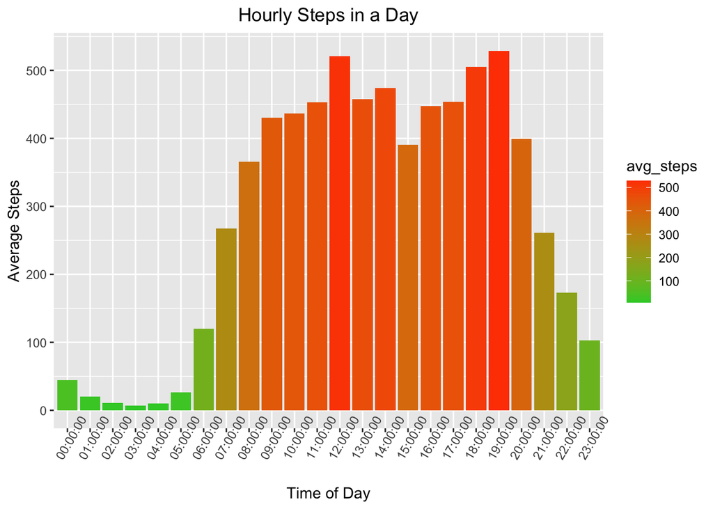

```r
hourly_steps %>%
  group_by(time) %>%
  summarize(avg_steps = mean(step_total, na.rm = TRUE)) %>%
  ggplot() +
  geom_col(mapping = aes(x=time, y = avg_steps, fill = avg_steps)) +
  labs(title = "Hourly Steps in a Day", x = "Time of Day", y = "Average Steps") +
  theme(plot.title = element_text(hjust = 0.5)) +
  theme(axis.text.x = element_text(angle = 60)) +
  scale_fill_gradient(low = "#32CD32", high = "#FF4500") +
  scale_y_continuous(breaks = seq(0, 1000, by = 100))
```

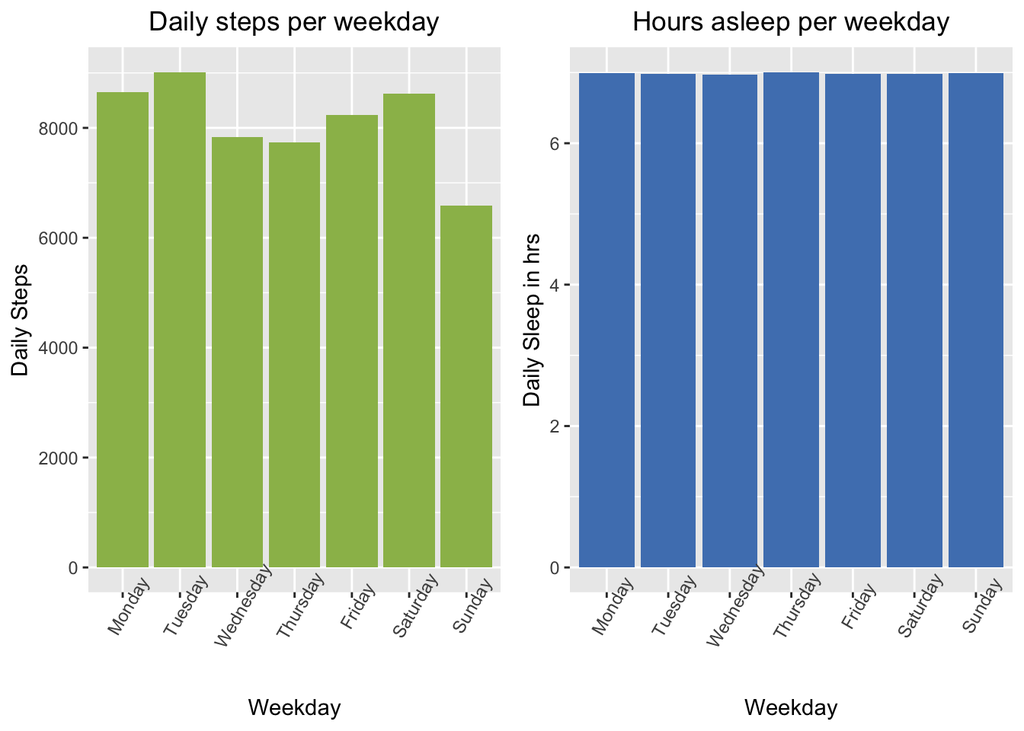

```r
ggarrange(
  ggplot(weekday_steps_sleep, aes(weekday, daily_steps)) +
    geom_col(fill = "#9BBB59") +
    labs(title = "Daily steps per weekday", x = "Weekday", y = "Daily Steps") +
    theme(axis.text.x = element_text(angle = 60)) +
    theme(plot.title = element_text(hjust = 0.5)) +
    scale_y_continuous(breaks = seq(0, 10000, by = 2000)),
  ggplot(weekday_steps_sleep, aes(weekday, daily_sleep_hrs)) +
    geom_col(fill = "#4F81BD") +
    labs(title = "Hours asleep per weekday", x = "Weekday", y = "Daily Sleep in hrs") +
    theme(axis.text.x = element_text(angle = 60)) +
    theme(plot.title = element_text(hjust = 0.5))
  )
```

Next, let’s visualize any correlation between these daily steps, saily sleep & calories burned and see what’s happening.

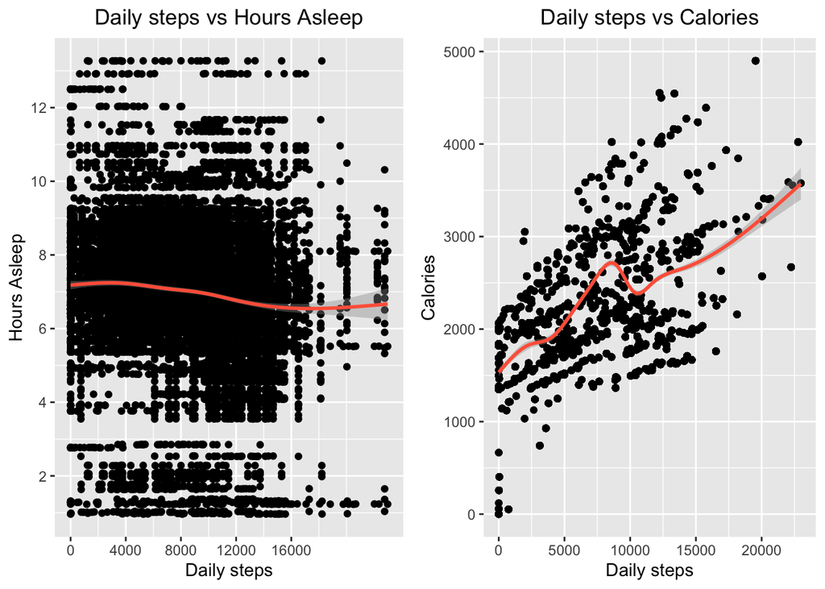

```r
ggarrange(
  ggplot(dailyActivity_total, aes(x=total_steps, y=total_minutes_asleep/60)) +
    geom_jitter() +
    geom_smooth(color = "#FF6347") +
    labs(title = "Daily steps vs Hours Asleep", x = "Daily steps", y= "Hours Asleep") +
    theme(plot.title = element_text(hjust = 0.5)) +
    scale_y_continuous(breaks = seq(0, 12, by= 2)) +
    scale_x_continuous(breaks = seq(0, 18000, by= 4000)),
  ggplot(dailyActivity_total, aes(x=total_steps, y=calories))+
    geom_jitter() +
    geom_smooth(color = "#FF6347") +
    labs(title = "Daily steps vs Calories", x = "Daily steps", y= "Calories") +
    theme(plot.title = element_text(hjust = 0.5))
)
```

Here we notice the following:

1. There seems to be no relation between hours asleep and daily steps taken in a day because more asleep does not equate to more steps taken or vice-versa
2. There is a positive correlation between daily steps taken and calories burned which makes sense as more steps burn more calories

Since we know that users are only sleeping ~ 7 hours during a weekday, lets visualize users not asleep

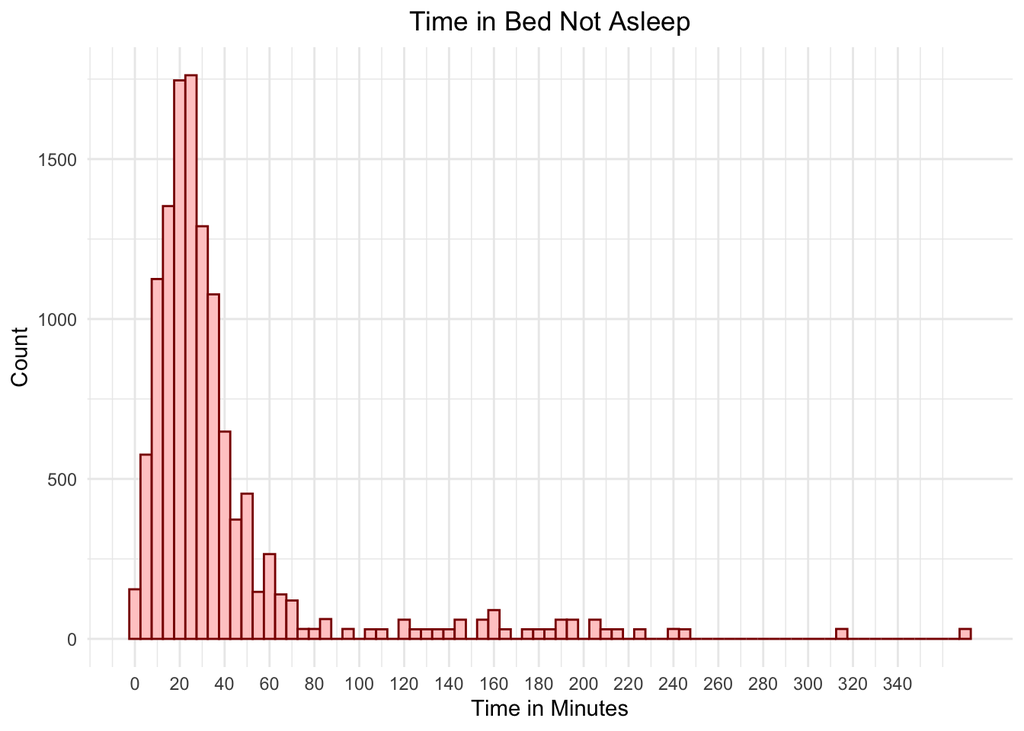

```r
ggplot(dailyActivity_total, aes(x= time_not_asleep)) +
  geom_histogram(binwidth = 5,color= "#8B0000", fill = "#FFCCCB") +
  scale_x_continuous(breaks = seq(0, 340, by = 20)) +
  theme_minimal() +
  labs(title = "Time in Bed Not Asleep", x = "Time in Minutes", y = "Count") +
  theme(plot.title = element_text(hjust = 0.5))
```

From the histogram we see that users are not asleep but still in bed from 10 - 30 minutes on average. I think we have some interesting data-points & visualizations from which we can draw some insightful conclusions that we can share with the stakeholders in the next phase.

## Phase 6: Act

The goal of the last phase is to utilize the analysis and visualizations done above and share some actionable insights to meet business goals.

### 6.1 Recommendations

The goal of this section is to provide high level recommendations to the stakeholders identified earlier based on the analysis done and patterns recognized.

[output not shown]